# Ecological Archives E095-075-A9

*Ecological Archives* E095-075-A9

Chun-Wei Chang, Takeshi Miki, Fuh-Kwo Shiah, Shuh-ji Kao, Jiunn-Tzong Wu, Akash R. Sastri, Chih-hao Hsieh. 2014. Linking secondary structure of individual size distribution with nonlinear size–trophic level relationship in food webs. *Ecology* 95:897–909. http://dx.doi.org/10.1890/13-0742.1

Appendix I. Sensitivity test for the baseline of stable isotope analysis.

We test whether our prediction is sensitive to different approaches of TL estimation. Specifically, we consider the time-integrated baseline to estimate the trophic level of zooplankton. Using a time-integrated baseline fulfills the fact that the stable isotope signature of an organism is a time-averaged result from its resources. To calculate the time-integrated baseline, it is necessary to determine the “time period to average”. Here, we use the turnover time of the plankton. The turnover time is determined from Brown et al. (2004), according to the temperature allometric relationship, ln(*P*e<sup>*E*/K*t*</sup>) = 25.22 + 0.76 ln *M* (or ln(*MP*<sup>-1</sup>) = 0.24 ln *M* + (*E*/k*T* - 25.22), (unit: ln(yr)), where *P* is production; *T* is temperature (K); *E* is the activation energy, and k is the Boltzmann constant. We specified *E*=0.7eV; *T* is determined from empirical measurements, and *M* is the mean body size of each size fraction. As such, the turnover time for each size fraction at each sampling date can be determined (Table I1).

Then, we calculated the time-average baseline over the period of turnover time and then determine the TL and size-TL relationships. The size-TL relationships estimated from the time-integrated method are similar with our original results (average 8.6% and 8.7% difference for the 2nd and 3rd order coefficients, respectively). Therefore, the predictions of our model are insensitive to different approaches of TL estimation. The similar results given by different TL estimations are probably due to the fact that the turnover times in the plankton community are short. Over the short turnover period, the change of isotopic signature of baselines is often insignificant.

Table I1. The turnover time (days) estimated from the allometric relationship for each size fraction.

| Size fraction (μm) | (1) >500 | (2) 500~177 | (3) 177~74 | (4) 74~44 | (5) 44~10 | (6) 10~0.7 |
| --- | --- | --- | --- | --- | --- | --- |
| Mean turnover rate±SD (day) | 32.6±9.0 | 14.4±4.0 | 7.3±2.0 | 4.7±1.3 | 2.3±0.6 | 0.5±0.1 |

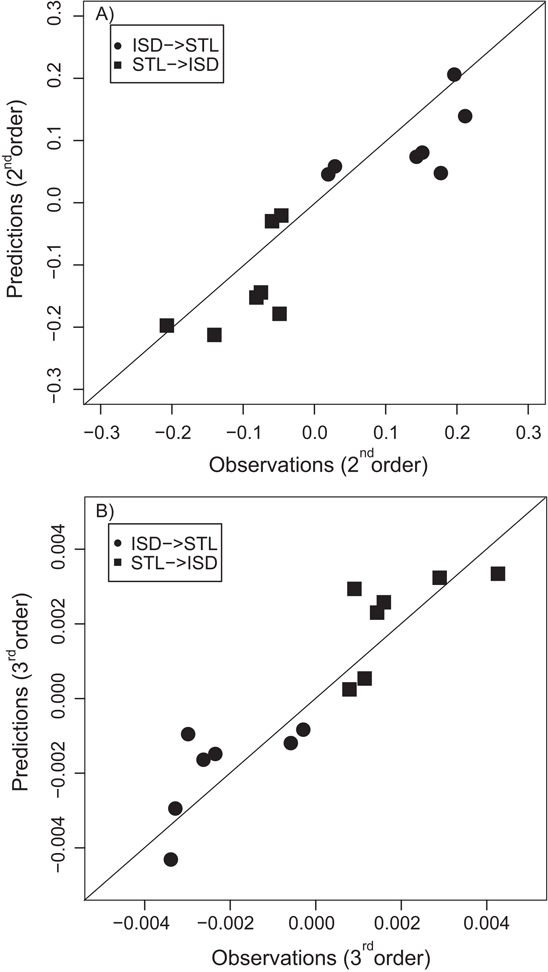

Fig. I1. Both the predictions on the (a) 2nd and (b) 3rd order polynomial coefficients are consistent with the observations by using the time-integrated baseline. The results are very similar with the results (Fig. 3A, B) based on the simple TL estimation by instantaneous baseline.

Literature cited

Brown, J. H., J. F. Gillooly, A. P. Allen, V. M. Savage, and G. B. West. 2004. Toward a metabolic theory of ecology. Ecology 85:1771–1789.

[Back to E095-075]